# Semiparametric Regression for Misclassified Competing Risks Data

Theofanis Balanos[^1]

Constantin T. Yiannoutsos[^2]

Felix M. Pabon-Rodriguez[^3]

Hongmei Nan[^4]

Giorgos Bakoyannis[^5]

In this short document, we present an example illustrating how to apply the proposed semiparametric regression method for misclassified competing risks data.

## Step 1 – Generate external validation dataset

We begin by generating a simulated external validation dataset for modeling misclassification probabilities in competing-risks data. The simulation mechanism follows the procedure described in Mpofu et al. (2020) for the double-sampling pseudo-likelihood framework, which allows for bidirectional misclassification between causes of failure. This external dataset is subsequently used to estimate the parameters of the misclassification model, which are then applied to the main analysis dataset when fitting the proposed semiparametric regression model.

The data-generation procedure is contained in a separate R script, `simulate_data.R`. This script defines three main scenarios:

1. Unidirectional misclassification
2. Bidirectional misclassification (equal probabilities)
3. Bidirectional misclassification (unequal probabilities)

Below, we load the simulation script, generate an external validation dataset under the bidirectional (equal) scenario (`cause_num = 2`), and inspect the first few rows of one example dataset.

```r
#--- Generate a list of external validation datasets --------------------------

# Load data-generation script (follows Mpofu et al. 2020 structure)
source("simulate_data.R")

# Arguments:
# n           : number of datasets to generate
# sample.size : number of subjects per dataset
# cause_num   : misclassification scenario
#               1 = uni-directional
#               2 = bi-directional (equal probabilities)
#               3 = bi-directional (unequal probabilities)
# ds          : proportion double-sampled (internal validation)

external_data_list <- data_list(n = 1,
                                sample.size = 500,
                                cause_num = 2,
                                ds = 1.0)   # full validation, true causes observed

# Select one dataset for demonstration if more than one is generated (here 1 is generated)
dat_external <- external_data_list[[1]]

# Display first few rows of the simulated external dataset
head(dat_external)
```

```
##   d1 d2         t          x        z1         z2 s r d1_obs d2_obs c_obs c id
## 1  1  0 0.3621348 0.36213477 0.7739886 -1.3304642 1 1      0      1     2 1  1
## 2  1  0 0.5556069 0.55560694 0.8347630  0.6273535 1 1      0      1     2 1  2
## 3  0  0 0.4072878 0.02007464 0.7385241 -0.8678493 0 1      0      0     0 0  3
## 4  0  1 1.1707636 1.17076358 0.6271958 -0.4445398 1 1      0      1     2 2  4
## 5  0  1 0.9566128 0.95661276 0.5045060 -0.5591339 1 1      1      0     1 2  5
## 6  0  0 0.9343368 0.87421236 0.9069824 -0.1255128 0 1      0      0     0 0  6
```

### Variable descriptions

Each simulated dataset generated by `simulate_data.R` contains the following variables:

| Variable | description |
| --- | --- |
| **id** | Subject identifier. |
| **t** | True failure time $T$. |
| **x** | Observed follow-up time (minimum of event or censoring time). |
| **c** | True cause of failure (1 = cause 1, 2 = cause 2, 0 = censored). |
| **c_obs** | Observed (possibly misclassified) cause of failure $C^{*}$. |
| **d1** | Indicator that the *true* cause of failure is 1 $(C=1)$. |
| **d2** | Indicator that the *true* cause of failure is 2 $(C=2)$. |
| **d1_obs** | Indicator that the *observed* cause of failure is 1 $(C^{*}=1)$. |
| **d2_obs** | Indicator that the *observed* cause of failure is 2 $(C^{*}=2)$. |
| **z1** | Continuous covariate 1 (Uniform (0, 1)). |
| **z2** | Continuous covariate 2 (Normal (0, 1)). |
| **s** | Double-sampling indicator (1 = subject selected for validation sample, 0 = not selected). |
| **r** | Indicator that the *true cause* is observed (1 = true cause known, 0 = missing). |

All variables are fully simulated and serve only illustrative purposes following the data-generation structure of *Mpofu et al.* (2020).

## Step 2 – Estimate misclassification probabilities

Next, we apply the pseudo-likelihood estimation procedure of *Mpofu et al.* (2020) to the external validation dataset generated in Step 1. This step estimates the parameters of the logistic-regression models for the predictive values and the misclassification probabilities. The estimated coefficients $\hat{\gamma}$ describe how covariates $(t, z_1, z_2)$ affect the probability of misclassifying one cause as another. In addition to the estimated coefficients, we obtain the corresponding estimated variance-covariance matrices $\hat{\Omega}$, which are later used to account for uncertainty in the estimated misclassification probabilities during bootstrap inference.

The estimation functions are defined in the external script `pseudo_likelihood_estimation_Mpofu.R`.

```r
#--- Load Mpofu et al. (2020) pseudo-likelihood estimation functions -----------
source("pseudo_likelihood_estimation_Mpofu.R")
```

### | Probability of observing cause 2 given true cause 1

In this case, we estimate the probability of observing cause 2 when the true cause of failure is 1; that is,

$$P(C^{*}=2 \mid C=1,\, T,\, Z)$$

representing misclassification from cause 1 → 2, and $T=t$ denotes the event time and $Z=(z_1,z_2)$ represents the subject-specific covariates.

```r
#--- Perform pseudo-likelihood estimation for cause 1 → 2 ---------------------
model_fit_example1 <- misclass_ps_est(dat = dat_external,
                                      true_out = "c",
                                      surr_out = "c_obs",
                                      out_interest = 1,
                                      formula_pred_val = ~ t + z1 + z2,
                                      formula_mis = ~ t + z1 + z2,
                                      ds_var = "r")

# Display estimated coefficients and standard errors
model_fit_example1$test_summary
```

```
##
## z test of coefficients:
##
##             Estimate Std. Error z value  Pr(>|z|)
## (Intercept) -0.69745    0.48467 -1.4390  0.150144
## t           -1.09269    0.52887 -2.0661  0.038822 *
## z1           1.58789    0.60285  2.6340  0.008439 **
## z2          -0.80591    0.20262 -3.9773 6.969e-05 ***
## ---
## Signif. codes:  0 '***' 0.001 '**' 0.01 '*' 0.05 '.' 0.1 ' ' 1
```

```r
# Store estimated coefficients and variance-covariance matrix
gamma_hat_21 <- model_fit_example1$parEst
Omega_hat_21 <- model_fit_example1$varEst
```

### | Probability of observing cause 1 given true cause 2

Here, we estimate the probability of observing cause 1 when the true cause of failure is 2; that is,

$$P(C^{*}=1 \mid C=2,\, T,\, Z)$$

representing misclassification from cause 2 → 1, and $T=t$ denotes the event time and $Z=(z_1,z_2)$ represents the subject-specific covariates.

```r
#--- Perform pseudo-likelihood estimation for cause 2 → 1 ---------------------
model_fit_example2 <- misclass_ps_est(dat = dat_external,
                                      true_out = "c",
                                      surr_out = "c_obs",
                                      out_interest = 2,
                                      formula_pred_val = ~ t + z1 + z2,
                                      formula_mis = ~ t + z1 + z2,
                                      ds_var = "r")

# Display estimated coefficients and standard errors
model_fit_example2$test_summary
```

```
##
## z test of coefficients:
##
##             Estimate Std. Error z value Pr(>|z|)
## (Intercept) -0.65537    0.44235 -1.4816 0.138459
## t           -0.68637    0.53554 -1.2816 0.199972
## z1           1.08815    0.66772  1.6297 0.103175
## z2          -0.78372    0.24652 -3.1792 0.001477 **
## ---
## Signif. codes:  0 '***' 0.001 '**' 0.01 '*' 0.05 '.' 0.1 ' ' 1
```

```r
# Store estimated coefficients and variance-covariance matrix
gamma_hat_12 <- model_fit_example2$parEst
Omega_hat_12 <- model_fit_example2$varEst
```

The estimated coefficient vectors $\hat{\gamma}_{12}$ and $\hat{\gamma}_{21}$, together with their corresponding variance-covariance matrices $\hat{\Omega}_{12}$ and $\hat{\Omega}_{21}$, are carried forward to the main analysis. These quantities are used to compute subject-specific misclassification probabilities and to account for uncertainty in the estimated misclassification model during bootstrap inference.

## Step 3 – Generate main analysis dataset

In this step, we generate a main analysis dataset representing the study cohort in which the true causes of failure are not observed. Only the observed, potentially misclassified causes ($C^{*}$) are available for analysis. This dataset will later be analyzed using the proposed semiparametric regression method, incorporating the externally estimated misclassification probabilities obtained in Step 2.

The same simulation procedure used for the external validation data is employed here (see `simulate_data.R`), but we set the double-sampling proportion (`ds = 0`) so that no subjects have their true causes observed.

```r
#--- Generate the main analysis dataset ---------------------------------------

# Load the simulation script (already loaded earlier, shown again for clarity)
source("simulate_data.R")

# Create one main dataset with no internal validation (ds = 0)
main_data_list <- data_list(n = 1,
                            sample.size = 1000,
                            cause_num = 2,   # bidirectional equal misclassification
                            ds = 0.0)        # no double-sampling (true causes unobserved)

dat_main <- main_data_list[[1]]

# Display first few rows of the main dataset
head(dat_main)
```

```
##   d1 d2         t           x        z1         z2 s r d1_obs d2_obs c_obs c id
## 1  1  0 0.3976505 0.397650545 0.7739886  2.1891931 0 0      1      0     1 1  1
## 2  0  0 1.3563747 0.908814338 0.8347630 -0.3297718 0 1      0      0     0 0  2
## 3  0  0 0.2343642 0.126619417 0.7385241  0.9515016 0 1      0      0     0 0  3
## 4  1  0 0.5846874 0.584687377 0.6271958  1.0476872 0 0      1      0     1 1  4
## 5  0  0 0.8882242 0.005048767 0.5045060 -1.0196852 0 1      0      0     0 0  5
## 6  1  0 0.2385472 0.238547182 0.9069824  1.3919903 0 0      1      0     1 1  6
```

#### Note

Variable definitions are the same as those described in Step 1. The externally estimated coefficient vectors and variance-covariance matrices obtained in Step 2 are subsequently used to compute subject-specific misclassification probabilities for this dataset and to account for uncertainty in the estimated misclassification model during bootstrap inference.

## Step 4 – Compute misclassification probabilities for the main dataset

We now compute the estimated misclassification probabilities for each subject in the main analysis dataset using the pseudo-likelihood models fitted on the external validation dataset (Step 2). Specifically,

- $p_{21} = P(C^{*}=2 \mid C=1, T, Z)$: probability that true cause 1 is observed as cause 2
- $p_{12} = P(C^{*}=1 \mid C=2, T, Z)$: probability that true cause 2 is observed as cause 1

The estimated coefficient vectors obtained in Step 2 are used to compute subject-specific misclassification probabilities for each individual in the main analysis dataset. These probabilities are subsequently incorporated into the proposed semiparametric regression model. During bootstrap inference, the probabilities are recalculated using regenerated misclassification model parameters to account for uncertainty in the estimated misclassification model.

```r
#--- Step 4: Compute predicted misclassification probabilities -----------------

# Extract Mpofu model objects from Step 2
mod_21 <- model_fit_example1$model_miscl   # C = 1 → observed as 2
mod_12 <- model_fit_example2$model_miscl   # C = 2 → observed as 1

# Predict misclassification probabilities in the main dataset
dat_main$p21 <- predict(mod_21, newdata = dat_main, type = "response")
dat_main$p12 <- predict(mod_12, newdata = dat_main, type = "response")

# Display first few rows with misclassification probabilities
head(dat_main[, c("t", "z1", "z2", "p12", "p21")])
```

```
##           t        z1         z2       p12       p21
## 1 0.3976505 0.7739886  2.1891931 0.1416310 0.1587927
## 2 1.3563747 0.8347630 -0.3297718 0.3966265 0.3570309
## 3 0.2343642 0.7385241  0.9515016 0.3190117 0.3664057
## 4 0.5846874 0.6271958  1.0476872 0.2323138 0.2341982
## 5 0.8882242 0.5045060 -1.0196852 0.5207665 0.4887178
## 6 0.2385472 0.9069824  1.3919903 0.2843262 0.3453057
```

## Step 5 – Apply the proposed semiparametric regression method

In this step, we apply the proposed semiparametric regression estimator to the main analysis dataset. This method uses the externally estimated misclassification probabilities $p_{12}$ and $p_{21}$ obtained in Step 4 to correct the cause-specific hazard estimation. The resulting estimates correspond to the analysis based on the estimated misclassification probabilities from the external validation study; uncertainty in these probabilities is incorporated later through the bootstrap procedure.

The estimation function `bssmle()` is defined in the external R script `bssmle.R`.

```r
#--- Load the proposed semiparametric regression function ---------------------
source("bssmle.R")

#--- Fit the model to the main dataset ----------------------------------------
# Specify which covariates to include (must match column names in dat_main)
fit_bssmle <- bssmle(dat_main, covariates = c("z1", "z2"))

#--- Interpretation helper ----------------------------------------------------
# The returned object 'fit_bssmle' is a numeric vector that concatenates:
#   (1) phi1: B-spline coefficients for baseline hazard of cause 1
#   (2) phi2: B-spline coefficients for baseline hazard of cause 2
#   (3) beta1: regression coefficients for cause 1
#   (4) beta2: regression coefficients for cause 2
#
# For q covariates and n spline basis functions, the total length is 2*n + 2*q.

covariates <- c("z1", "z2")   # keep consistent with the function call above

beta_vec <- fit_bssmle
q <- length(covariates)

# Recover number of spline basis coefficients per cause
n <- (length(beta_vec) - 2*q) / 2
stopifnot(n == floor(n), n > 0)

#--- Extract parameter blocks -------------------------------------------------
phi1  <- beta_vec[1:n]                      # baseline hazard coefficients, cause 1
phi2  <- beta_vec[(n+1):(2*n)]              # baseline hazard coefficients, cause 2
beta1 <- beta_vec[(2*n+1):(2*n+q)]          # regression coefs, cause 1
beta2 <- beta_vec[(2*n+q+1):(2*n+2*q)]      # regression coefs, cause 2

#--- Label and present the regression coefficients ---------------------------
names(beta1) <- paste0("Cause1:", covariates)
names(beta2) <- paste0("Cause2:", covariates)

coef_table <- data.frame(
  cause     = rep(c("Cause 1","Cause 2"), each = q),
  covariate = rep(covariates, times = 2),
  estimate  = c(beta1, beta2)
)

cat("\nEstimated regression coefficients for each cause:\n")
```

```
##
## Estimated regression coefficients for each cause:
```

```r
print(coef_table, row.names = FALSE)
```

```
##    cause covariate    estimate
##  Cause 1        z1 -0.14669486
##  Cause 1        z2  1.38315257
##  Cause 2        z1 -0.00129013
##  Cause 2        z2  0.31887542
```

```r
cat("\nNumber of B-spline basis coefficients per cause:", n, "\n")
```

```
##
## Number of B-spline basis coefficients per cause: 13
```

#### Notes

- The vector `fit_bssmle` concatenates all estimated parameters in the order $(\phi_1, \phi_2, \beta_1, \beta_2)$.
  - $\phi_1, \phi_2$: spline coefficients describing the two baseline hazards.
  - $\beta_1, \beta_2$: regression coefficients for the covariates under each cause.
- With two covariates $(z_1, z_2)$, the **last four elements** of `fit_bssmle` correspond to $(\beta_{1,z1}, \beta_{1,z2}, \beta_{2,z1}, \beta_{2,z2})$.
- These estimates incorporate the externally derived misclassification probabilities, providing bias-corrected cause-specific hazard estimates under time- and covariate-dependent misclassification.

## Step 6 – Sensitivity analysis for misclassification probabilities

The proposed method relies on the *transportability assumption*: the misclassification probabilities estimated from the external validation dataset apply to the main study population. Following Section 4 of the paper, we examine the robustness of the method to violations of this assumption through a sensitivity analysis indexed by a parameter $\eta$.

Let $S = 1$ denote the main study sample and $S = 0$ the external validation study sample. The transportability assumption states that
$$P(C^* = j \mid C = h, S = 0, T = t, Z = z)
= P(C^* = j \mid C = h, S = 1, T = t, Z = z)
= g_{jh}\!\left(\gamma_{0,jh}^{\top} \tilde{W}\right),$$
where $g_{jh}(\cdot)$ is the inverse of a link function corresponding to the misclassification probability from true cause $h$ to observed cause $j$, $\gamma_{0,jh}$ is the unknown parameter vector estimated from the external validation sample, and $\tilde{W} = (1, T, Z^{\top})^{\top}$. If the transportability assumption is violated, the last equality does not hold. For such situations, we define
$$P(C^* = j \mid C = h, S, T = t, Z = z)
= g_{jh}\!\left(\gamma_{0,jh}^{\top}\tilde{W} + \eta S\right).$$
When $\eta = 0$, transportability holds; when $\eta \neq 0$, it is violated.

For $k = 2$ and a logistic model for the misclassification probability, $\eta$ has a direct interpretation as a log odds ratio, comparing the odds of observing $C^* = j$ in the main dataset ($S = 1$) to the odds in the external validation dataset ($S = 0$), conditional on $C = h$, $T$, and $Z$:
$$\eta = \log\!\left(
\frac{P(C^* = j \mid C = h, S = 1, T, Z)\,\big/\,[1 - P(C^* = j \mid C =
h, S = 1, T, Z)]}
{P(C^* = j \mid C = h, S = 0, T, Z)\,\big/\,[1 - P(C^* = j \mid C =
h, S = 0, T, Z)]}
\right).$$

In practice, because the main study corresponds to $S = 1$, incorporating $\eta$ is equivalent to applying a logit shift to the estimated misclassification probabilities
$$p_{21} = P(C^{*}=2 \mid C=1,\, T=t,\, Z), \qquad
p_{12} = P(C^{*}=1 \mid C=2,\, T=t,\, Z):$$
$$\mathrm{logit}\!\left\{p_{jh}^{(\eta)}\right\}
= \mathrm{logit}\!\left\{p_{jh}\right\} + \eta,
\quad\text{so}\quad
p_{jh}^{(\eta)} = \mathrm{logit}^{-1}\!\left\{\mathrm{logit}(p_{jh}) +
\eta\right\}.$$

For each $\eta \in \{-0.5, -0.25, 0, 0.25, 0.5\}$, the pseudo-likelihood in equation (3) of the paper is maximized using `bssmle()` with the adjusted misclassification probabilities. In the bootstrap step, this same sensitivity adjustment can be applied after regenerating the misclassification model parameters, so that both transportability sensitivity and uncertainty in the estimated misclassification probabilities are reflected in the inference.

```r
#--- Sensitivity analysis implementation (bidirectional adjustment) -----------

etas <- c(-0.5, -0.25, 0, 0.25, 0.5)
covariates <- c("z1", "z2")

fit_at_eta <- function(eta, dat, covariates) {
  dat_eta <- dat

  if (abs(eta) > 1e-12) {
    eps <- 1e-12

    # Adjust p21 (C=1 → observed as 2)
    p <- pmin(pmax(dat_eta$p21, eps), 1 - eps)
    dat_eta$p21 <- plogis(qlogis(p) + eta)

    # Adjust p12 (C=2 → observed as 1)
    p <- pmin(pmax(dat_eta$p12, eps), 1 - eps)
    dat_eta$p12 <- plogis(qlogis(p) + eta)
  }
  # else leave dat_eta$p12 and dat_eta$p21 unchanged

  beta_vec <- bssmle(dat_eta, covariates)

  q <- length(covariates)
  n <- (length(beta_vec) - 2*q) / 2
  if (!is.finite(n) || n != floor(n) || n <= 0) return(NULL)

  beta1 <- beta_vec[(2*n + 1):(2*n + q)]
  beta2 <- beta_vec[(2*n + q + 1):(2*n + 2*q)]
  names(beta1) <- paste0("Cause1:", covariates)
  names(beta2) <- paste0("Cause2:", covariates)

  coef_table <- data.frame(
    eta       = eta,
    cause     = rep(c("Cause 1", "Cause 2"), each = q),
    covariate = rep(covariates, times = 2),
    estimate  = c(beta1, beta2)
  )

  cat("\nEstimated regression coefficients for each cause (eta =", eta, "):\n")
  print(coef_table, row.names = FALSE)
  return(coef_table)
}

# Run sensitivity analysis across η values
sens_list <- lapply(etas, fit_at_eta, dat = dat_main, covariates = covariates)
```

```
##
## Estimated regression coefficients for each cause (eta = -0.5 ):
##   eta   cause covariate    estimate
##  -0.5 Cause 1        z1 -0.10863729
##  -0.5 Cause 1        z2  1.29790132
##  -0.5 Cause 2        z1 -0.01123548
##  -0.5 Cause 2        z2  0.33141168
##
## Estimated regression coefficients for each cause (eta = -0.25 ):
##    eta   cause covariate     estimate
##  -0.25 Cause 1        z1 -0.146612041
##  -0.25 Cause 1        z2  1.362897154
##  -0.25 Cause 2        z1  0.002241772
##  -0.25 Cause 2        z2  0.321675163
##
## Estimated regression coefficients for each cause (eta = 0 ):
##  eta   cause covariate    estimate
##    0 Cause 1        z1 -0.14669486
##    0 Cause 1        z2  1.38315257
##    0 Cause 2        z1 -0.00129013
##    0 Cause 2        z2  0.31887542
##
## Estimated regression coefficients for each cause (eta = 0.25 ):
##   eta   cause covariate    estimate
##  0.25 Cause 1        z1 -0.02498675
##  0.25 Cause 1        z2  1.29024182
##  0.25 Cause 2        z1 -0.06795085
##  0.25 Cause 2        z2  0.31510318
##
## Estimated regression coefficients for each cause (eta = 0.5 ):
##  eta   cause covariate    estimate
##  0.5 Cause 1        z1  0.02178176
##  0.5 Cause 1        z2  1.11322806
##  0.5 Cause 2        z1 -0.11152170
##  0.5 Cause 2        z2  0.30700841
```

#### Note

Please note here that results for $\eta = 0$ correspond to those from Step 5, since $\eta = 0$ represents the baseline case without any sensitivity adjustment.

## Step 7 – Bootstrap standard errors

To assess the sampling variability of the proposed estimator, we use a bootstrap procedure that accounts for uncertainty in both the main analysis data and the estimated misclassification model. For each bootstrap replicate, individuals are resampled with replacement from the main dataset. In addition, new values of the misclassification-model parameters are generated using the estimated coefficient vectors and their corresponding variance-covariance matrices obtained in Step 2.

The regenerated parameters are then used to recompute subject-specific misclassification probabilities, which are incorporated into the proposed semiparametric regression model. This allows uncertainty from the external validation study to be reflected in the final regression inference.

For demonstration, we use 10 bootstrap samples, but users can increase this number (e.g., 100 or 1000) depending on computational resources and needs. The bootstrap is performed only for the baseline case with $\eta = 0$, and not for the sensitivity analyses in Step 6.

```r
set.seed(2026)  # for reproducibility
n_boot <- 10    # number of bootstrap replicates (adjust as needed)
covariates <- c("z1", "z2")

#--- Helper function to avoid probabilities exactly equal to 0 or 1 ------------
trim_prob <- function(p, eps = 1e-8) {
  pmin(pmax(p, eps), 1 - eps)
}

#--- Helper function to compute p21 from a regenerated gamma vector ------------
compute_p21_boot <- function(dat, gamma_vec) {
  names(gamma_vec) <- names(gamma_hat_21)

  lp <- gamma_vec["(Intercept)"] +
    gamma_vec["t"]  * dat$t +
    gamma_vec["z1"] * dat$z1 +
    gamma_vec["z2"] * dat$z2

  plogis(lp)
}

#--- Helper function to compute p12 from a regenerated gamma vector ------------
compute_p12_boot <- function(dat, gamma_vec) {
  names(gamma_vec) <- names(gamma_hat_12)

  lp <- gamma_vec["(Intercept)"] +
    gamma_vec["t"]  * dat$t +
    gamma_vec["z1"] * dat$z1 +
    gamma_vec["z2"] * dat$z2

  plogis(lp)
}

#--- Bootstrap procedure ------------------------------------------------------
# Expected length of bssmle() output, used to pad failed fits with NA
expected_len <- length(fit_bssmle)

boot_results <- replicate(n_boot, {

  # Resample individuals with replacement
  idx <- sample(seq_len(nrow(dat_main)), replace = TRUE)
  dat_boot <- dat_main[idx, ]

  # Regenerate misclassification-model parameters using gamma-hat and Omega-hat
  gamma_12_b <- MASS::mvrnorm(n = 1,
                              mu = gamma_hat_12,
                              Sigma = Omega_hat_12,
                              tol = 1e-6)

  gamma_21_b <- MASS::mvrnorm(n = 1,
                              mu = gamma_hat_21,
                              Sigma = Omega_hat_21,
                              tol = 1e-6)

  # Recompute misclassification probabilities in the bootstrap sample
  dat_boot$p21 <- trim_prob(compute_p21_boot(dat_boot, gamma_21_b))
  dat_boot$p12 <- trim_prob(compute_p12_boot(dat_boot, gamma_12_b))

  # Fit the model on each bootstrap sample
  res <- bssmle(dat_boot, covariates = covariates)

  # Ensure every replicate returns a vector of the expected length so that
  # replicate() produces a proper matrix even if some fits fail to converge
  if (length(res) != expected_len) rep(NA_real_, expected_len) else res

}, simplify = "array")

# Compute bootstrap-based standard deviations (SEs)
boot_sds <- apply(boot_results, 1, sd, na.rm = TRUE)

#--- Summarize bootstrap inference results ------------------------------------

# Direct model fit from Step 5
theta_hat <- fit_bssmle

# Extract regression coefficients
q <- length(covariates)
n <- (length(theta_hat) - 2*q) / 2
stopifnot(n == floor(n), n > 0)

beta1_hat <- theta_hat[(2*n + 1):(2*n + q)]
beta2_hat <- theta_hat[(2*n + q + 1):(2*n + 2*q)]

# Extract corresponding bootstrap SEs
beta1_se <- boot_sds[(2*n + 1):(2*n + q)]
beta2_se <- boot_sds[(2*n + q + 1):(2*n + 2*q)]

# Wald statistics centered at direct fit
boot_table <- data.frame(
  cause     = rep(c("Cause 1", "Cause 2"), each = q),
  covariate = rep(covariates, times = 2),
  estimate  = c(beta1_hat, beta2_hat),
  SE        = c(beta1_se, beta2_se)
)

boot_table$z_value <- boot_table$estimate / boot_table$SE
boot_table$p_value <- 2 * (1 - pnorm(abs(boot_table$z_value)))
boot_table$Lower95 <- boot_table$estimate - 1.96 * boot_table$SE
boot_table$Upper95 <- boot_table$estimate + 1.96 * boot_table$SE

knitr::kable(
  boot_table,
  digits = c(NA, NA, 3, 3, 3, 3, 3, 3),
  caption = "Bootstrap-based Wald inference for regression coefficients, accounting for uncertainty in the estimated misclassification probabilities."
)
```

Bootstrap-based Wald inference for regression coefficients, accounting for uncertainty in the estimated misclassification probabilities.

| cause | covariate | estimate | SE | z_value | p_value | Lower95 | Upper95 |
| --- | --- | --- | --- | --- | --- | --- | --- |
| Cause 1 | z1 | -0.147 | 0.584 | -0.251 | 0.802 | -1.291 | 0.997 |
| Cause 1 | z2 | 1.383 | 0.148 | 9.374 | 0.000 | 1.094 | 1.672 |
| Cause 2 | z1 | -0.001 | 0.597 | -0.002 | 0.998 | -1.171 | 1.168 |
| Cause 2 | z2 | 0.319 | 0.109 | 2.932 | 0.003 | 0.106 | 0.532 |

#### Notes

- The number of bootstrap replicates (`n_boot`) can be increased to improve accuracy.
- Each bootstrap replicate resamples individuals and regenerates the misclassification-model parameters using their estimated variance-covariance matrices.
- Each bootstrap fit may take a few seconds to minutes depending on dataset size and computing power.

**Tip for readers:**  
Use `n_boot = 100` for a quick precision check, or `n_boot = 1000` for publication-grade inference.

## Step 8 – Plot cumulative incidence functions across η values

In this final step, we illustrate how the estimated cumulative incidence functions (CIFs) change under different sensitivity settings for the parameter $\eta$. Recall that $\eta$ controls the degree of deviation between the misclassification mechanism in the main study and the one estimated from the validation data. By refitting the semiparametric model for five values of $\eta = \{-0.5, -0.25, 0, 0.25, 0.5\}$, we can visualize how the predicted event probabilities evolve when assuming weaker or stronger transportability of the misclassification model.

To make the comparison meaningful, we evaluate the CIFs for a **representative subject**, defined as one whose continuous covariates $z_1$ and $z_2$ are set to their sample means. For each $\eta$, the function `bssmle()` is re-fitted using the adjusted misclassification probabilities and the resulting spline coefficients and regression parameters are used to reconstruct the **baseline hazards**, **cause-specific hazards** and the **CIFs** over a fine time grid. The CIFs in this step are computed using the fitted cumulative hazards and regression parameters obtained from our semiparametric proportional cause-specific hazards model. Specifically, for each cause $j = 1, 2$, the baseline cumulative hazard is estimated as
$$\hat{\Lambda}_{0j}(t) = \exp\{ \mathbf{B}(t)^{\top}
\hat{\boldsymbol{\phi}}_j \},$$
where $\mathbf{B}(t)$ denotes the B-spline basis functions and $\hat{\boldsymbol{\phi}}_j$ are the corresponding spline coefficients.

The subject-specific cumulative hazards are then given by
$$\hat{\Lambda}_j(t \mid Z) = \hat{\Lambda}_{0j}(t)
\exp(Z^{\top}\hat{\boldsymbol{\beta}}_j),$$
and the overall survival function is
$$\hat{S}(t \mid Z) = \exp\!\left[-\sum_{j=1}^{2}\hat{\Lambda}_j(t \mid
Z)\right].$$

Finally, the cumulative incidence function for cause $j$ is obtained by numerical integration of the cause-specific hazard over time:
$$\hat{F}_j(t \mid Z) = \int_0^t \hat{S}(u \mid Z)\, d\hat{\Lambda}_j(u
\mid Z),$$
which is approximated using cumulative sums over a fine time grid. These formulas correspond directly to the proportional cause-specific hazards formulation and the cumulative incidence representation of the paper.

The resulting plots display two panels, one for each cause of failure. The x-axis represents time and the y-axis shows the estimated probability of experiencing each event by time $t$ (ranging from 0 to 1). Each curve corresponds to a specific $\eta$ value, allowing a visual assessment of how sensitive the estimated CIFs are to plausible deviations from the baseline misclassification assumptions.

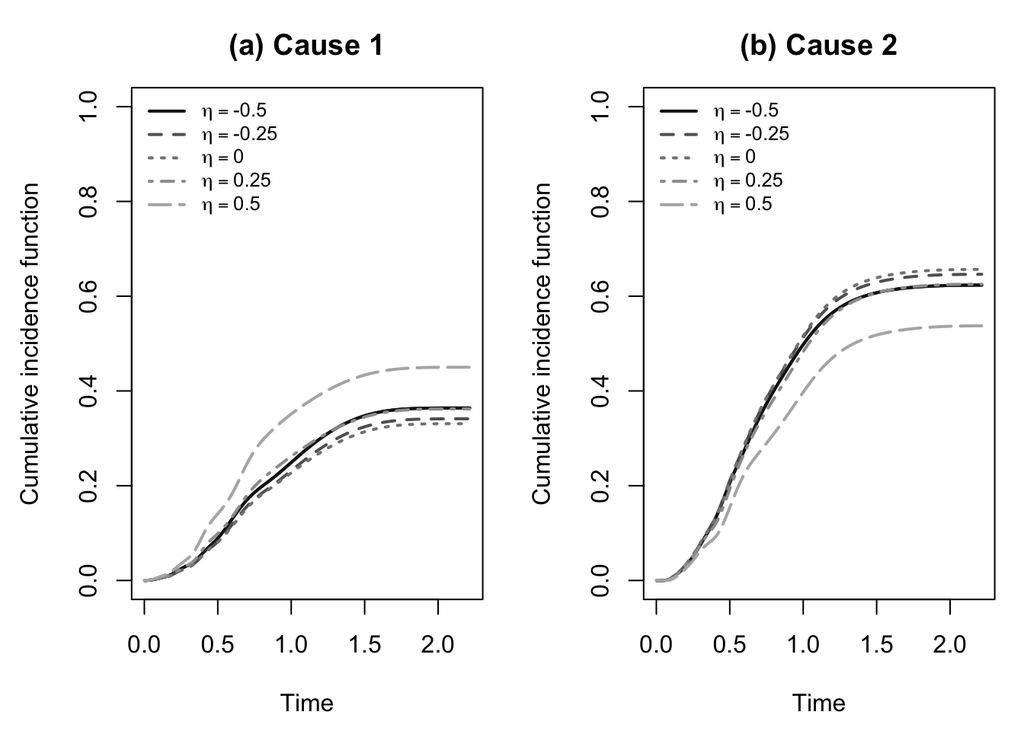

```r
#-----------------------------------------------#
# Plot CIFs for the five η scenarios
#-----------------------------------------------#

library(splines)

# Sensitivity parameters to test
etas <- c(-0.5, -0.25, 0, 0.25, 0.5)
covariates <- c("z1", "z2")
q <- length(covariates)

# Define a representative subject profile:
#   all continuous covariates set to their sample means
Z1 <- sapply(covariates, function(v) mean(dat_main[[v]], na.rm = TRUE))
Z2 <- Z1

# --- Fit the semiparametric model for each η value ---
# Each fit adjusts the misclassification probabilities by a logit shift of size η
fit_eta <- lapply(etas, function(eta) {
  dat_eta <- dat_main
  eps <- 1e-12
  dat_eta$p21 <- plogis(qlogis(pmin(pmax(dat_eta$p21, eps), 1 - eps)) + eta)
  dat_eta$p12 <- plogis(qlogis(pmin(pmax(dat_eta$p12, eps), 1 - eps)) + eta)
  bssmle(dat_eta, covariates = covariates)
})
names(fit_eta) <- paste0("eta_", etas)

# --- Build spline basis for the time grid ---
# This recreates the same spline setup used during model estimation (see function `bssmle()`)
t_fit <- dat_main$x
nk <- floor(length(t_fit)^(1/3))                              # number of interior knots
knots_fit <- quantile(t_fit, seq(0, 1, by = 1/(nk + 1)))[2:(nk + 1)]
bkn_fit   <- range(t_fit, na.rm = TRUE)
deg_fit   <- 3                                                # cubic B-splines
t_grid <- seq(bkn_fit[1], bkn_fit[2], length.out = 200)       # fine time grid
Bpred  <- bs(t_grid, knots = knots_fit, degree = deg_fit,
             intercept = TRUE, Boundary.knots = bkn_fit)
dt <- diff(t_grid)
dt <- c(dt[1], dt)                                            # match length of t_grid

# --- Function to compute CIFs from model coefficients ---
# Adapts automatically to the number of covariates q
compute_cif <- function(res, Bpred, Z1, Z2, t_grid, dt, q) {
  n  <- (length(res) - 2*q) / 2
  phi1 <- res[1:n]
  phi2 <- res[(n + 1):(2*n)]
  b1   <- res[(2*n + 1):(2*n + q)]
  b2   <- res[(2*n + q + 1):(2*n + 2*q)]

  # Baseline cumulative hazards
  H01 <- exp(Bpred %*% phi1)
  H02 <- exp(Bpred %*% phi2)

  # Subject-specific cumulative hazards
  lp1 <- sum(Z1 * b1); lp2 <- sum(Z2 * b2)
  H1 <- H01 * exp(lp1)
  H2 <- H02 * exp(lp2)

  # Instantaneous hazards and CIFs
  h1 <- c(0, diff(H1)) / dt
  h2 <- c(0, diff(H2)) / dt
  h1[!is.finite(h1)] <- 0; h2[!is.finite(h2)] <- 0

  S_t <- exp(-(H1 + H2))             # survival function
  F1  <- cumsum(S_t * h1 * dt)       # CIF for cause 1
  F2  <- cumsum(S_t * h2 * dt)       # CIF for cause 2
  list(F1 = F1, F2 = F2)
}

# --- Compute CIFs for all η values ---
cif_list <- lapply(fit_eta, compute_cif, Bpred = Bpred,
                   Z1 = Z1, Z2 = Z2, t_grid = t_grid, dt = dt, q = q)

# --- Plot the CIFs for each cause ---
# y-axis fixed between 0 and 1 for comparability
par(mfrow = c(1, 2), mar = c(4.5, 4.5, 3, 1))
cols <- gray.colors(length(etas), start = 0.1, end = 0.7)

## (a) Cause 1
plot(t_grid, cif_list[[1]]$F1, type = "l", lwd = 2, ylim = c(0, 1),
     xlab = "Time", ylab = "Cumulative incidence function",
     main = "(a) Cause 1")
for (i in seq_along(etas)) {
  lines(t_grid, cif_list[[i]]$F1, col = cols[i], lwd = 2, lty = i)
}
legend("topleft", legend = sapply(etas, \(e) bquote(eta == .(e))),
       col = cols, lwd = 2, lty = seq_along(etas),
       bty = "n", cex = 0.8)

## (b) Cause 2
plot(t_grid, cif_list[[1]]$F2, type = "l", lwd = 2, ylim = c(0, 1),
     xlab = "Time", ylab = "Cumulative incidence function",
     main = "(b) Cause 2")
for (i in seq_along(etas)) {
  lines(t_grid, cif_list[[i]]$F2, col = cols[i], lwd = 2, lty = i)
}
legend("topleft", legend = sapply(etas, \(e) bquote(eta == .(e))),
       col = cols, lwd = 2, lty = seq_along(etas),
       bty = "n", cex = 0.8)
```

## Concluding remarks

This example illustrated how to apply the proposed semiparametric regression method for competing risks data with misclassified causes of failure. Using simulated data, we demonstrated how to estimate misclassification probabilities from an external validation sample, fit the proposed model using these probabilities, account for uncertainty in the estimated misclassification model during bootstrap inference, and assess robustness through sensitivity analysis. The approach yields corrected and interpretable estimates of cause-specific effects and cumulative incidence functions, providing a practical framework for analyzing competing risks data subject to outcome misclassification.

[^1]: Department of Biostatistics and Health Data Science, Fairbanks School of Public Health and School of Medicine, Indiana University Indianapolis, IN, USA
[^2]: Department of Epidemiology and Biostatistics, CUNY Graduate School of Public Health and Health Policy, City University of New York, NY, USA
[^3]: Department of Biostatistics and Health Data Science, Fairbanks School of Public Health and School of Medicine, Indiana University Indianapolis, IN, USA
[^4]: Department of Epidemiology, Richard M. Fairbanks School of Public Health, Indiana University Indianapolis, IN, USA
[^5]: Department of Biostatistics and Health Data Science, Fairbanks School of Public Health and School of Medicine, Indiana University Indianapolis, IN, USA